# Cladistic analysis of Maya king lists

1. L
2. Top

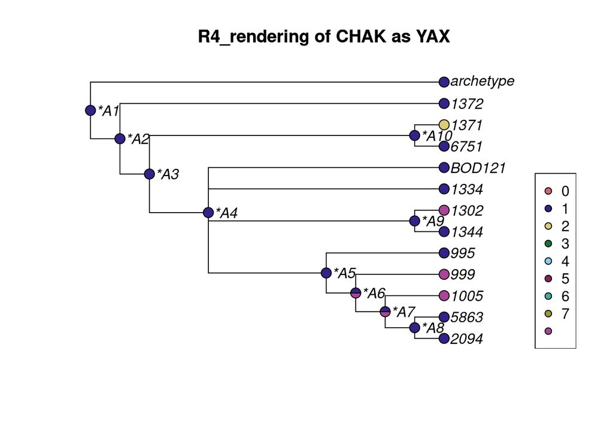

**Legend**

1. chak
2. yax

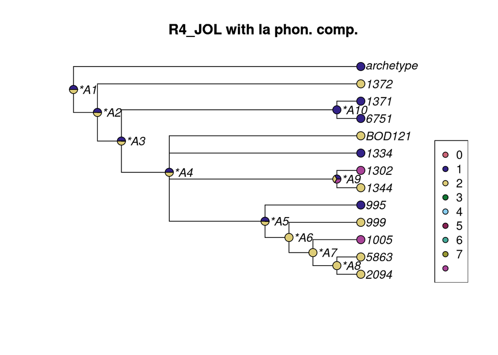

**Legend**

1. la
2. Ø

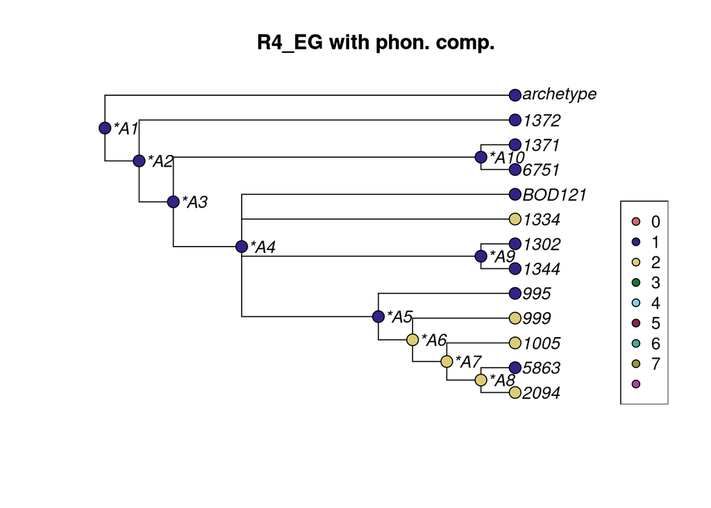

**Legend**

1. la
2. Ø

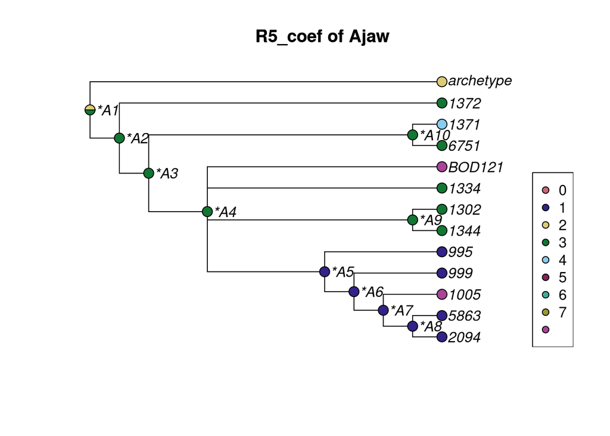

**Legend**

1. 12 w/ filler
2. 12/13
3. 13
4. 7 w/ filler

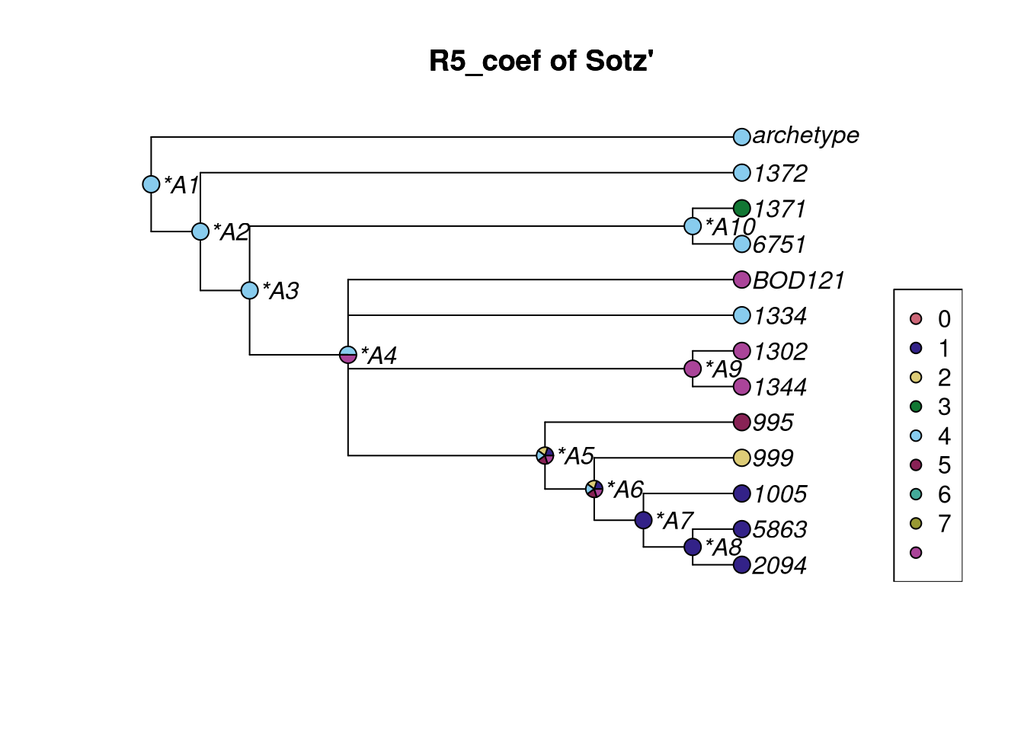

**Legend**

1. 4
2. 4?
3. 7 w/ filler
4. 8
5. 9

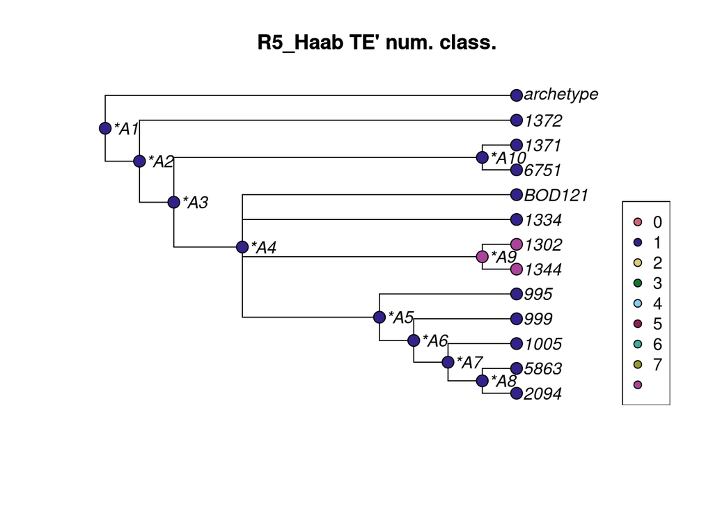

**Legend**

1. Yes

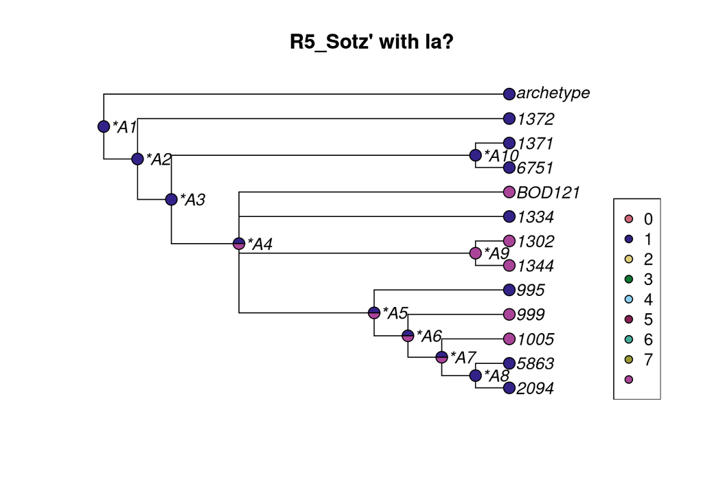

**Legend**

1. la

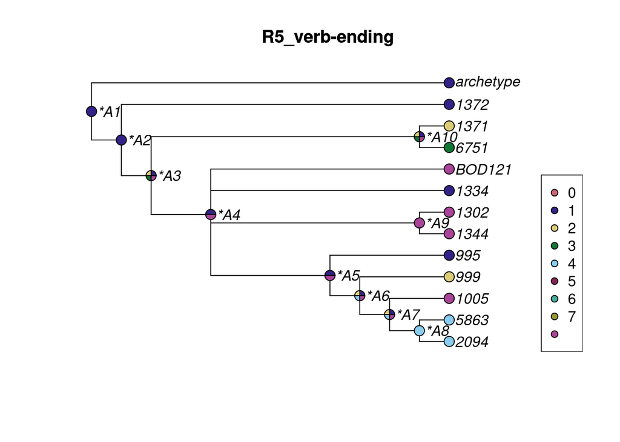

**Legend**

1. la
2. Ø
3. wa
4. ya

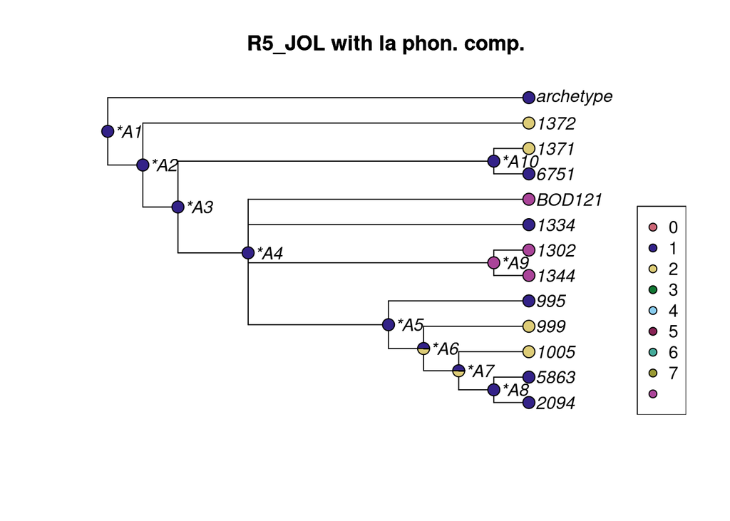

**Legend**

1. la
2. Ø

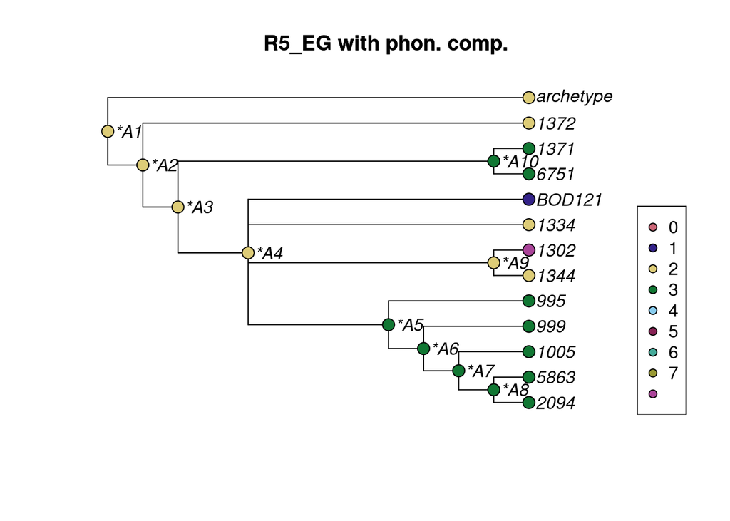

**Legend**

1. ―
2. la
3. Ø

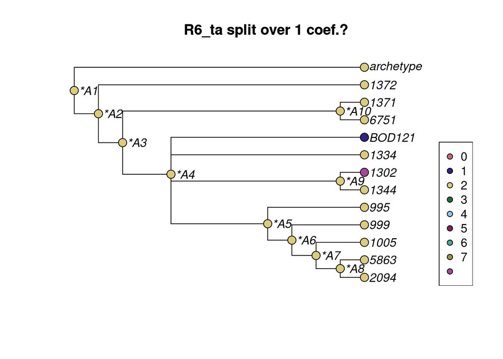

**Legend**

1. ―
2. Yes

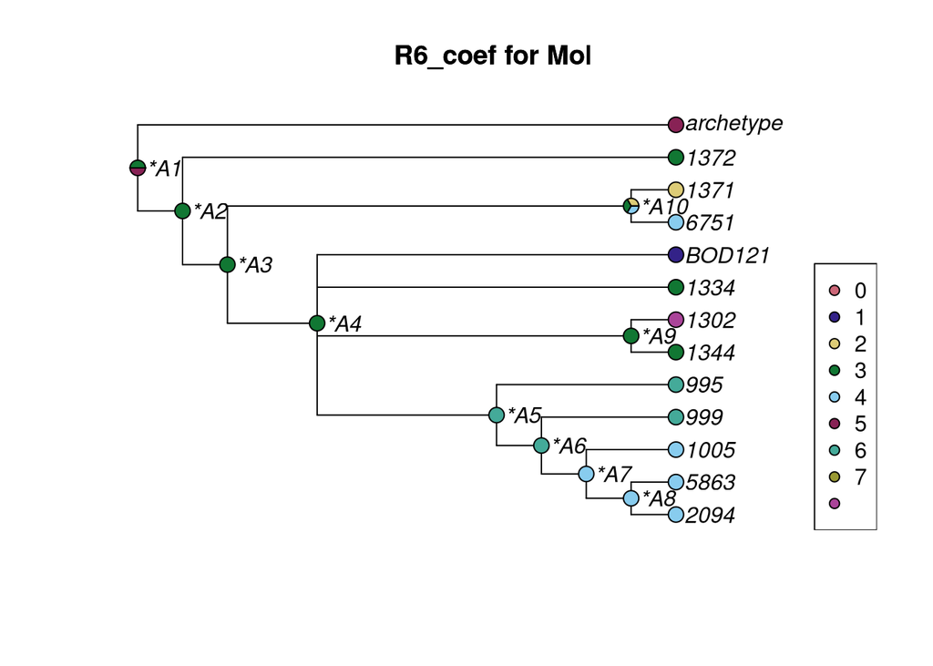

**Legend**

1. ―
2. 10
3. 11 w/ fillers
4. 12 w/ filler
5. 14
6. Ø

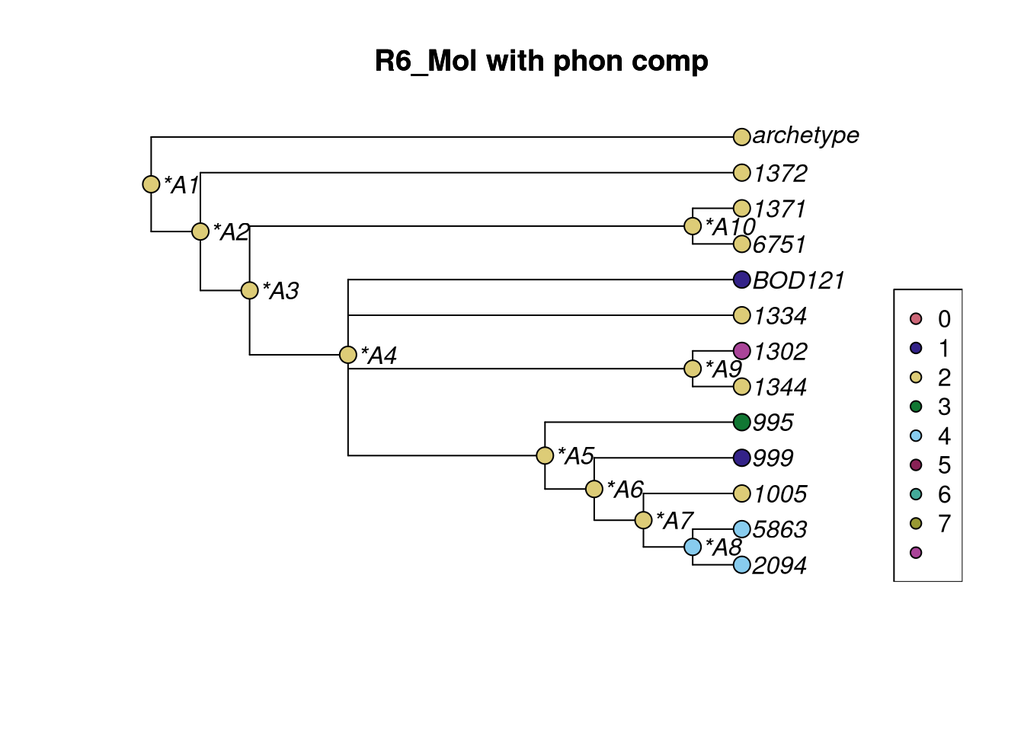

**Legend**

1. ―
2. la
3. Ø
4. ya

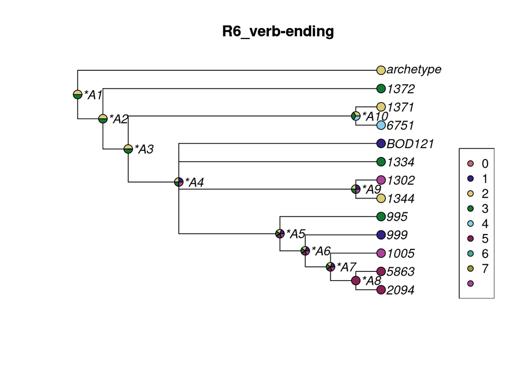

**Legend**

1. ―
2. la
3. Ø
4. wa
5. ya

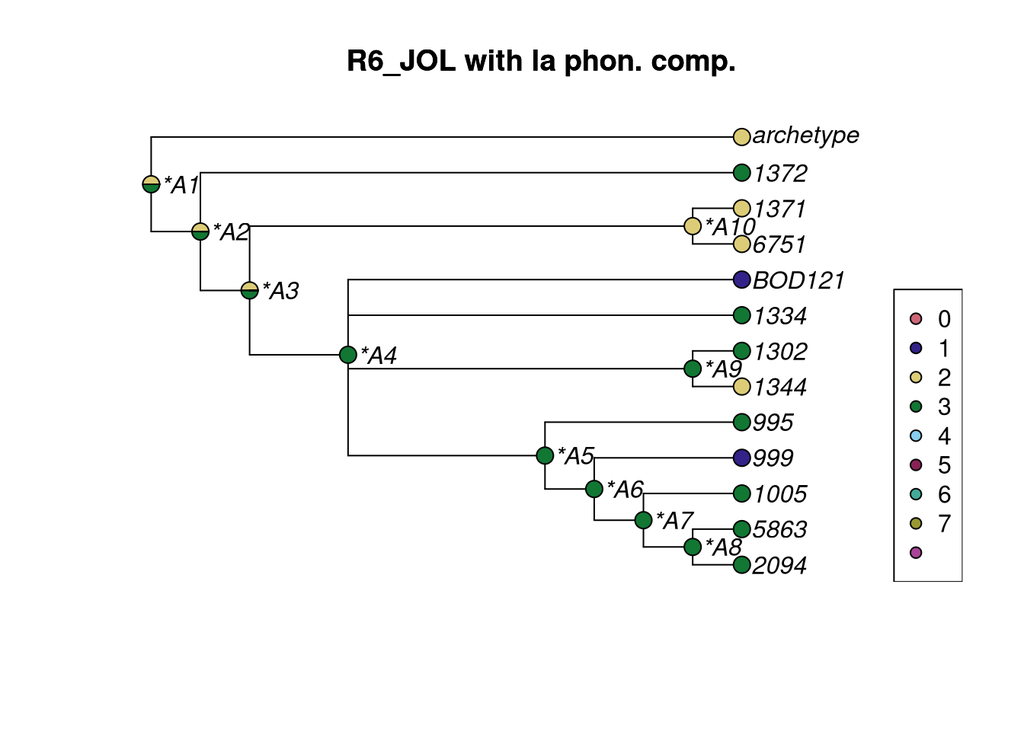

**Legend**

1. ―
2. la
3. Ø

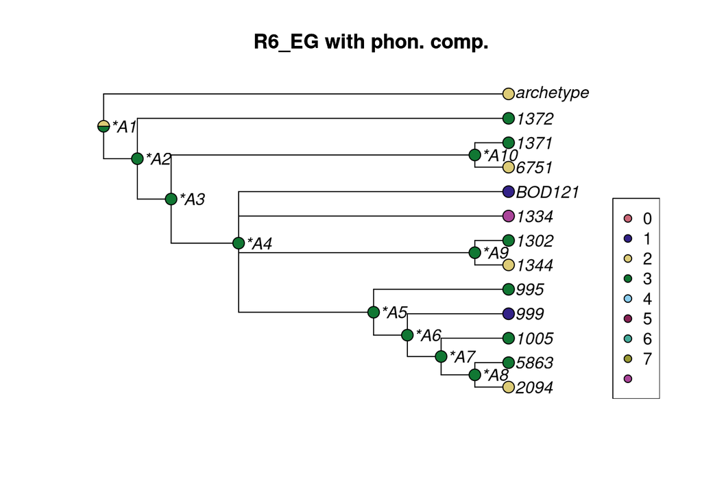

**Legend**

1. ―
2. la
3. Ø

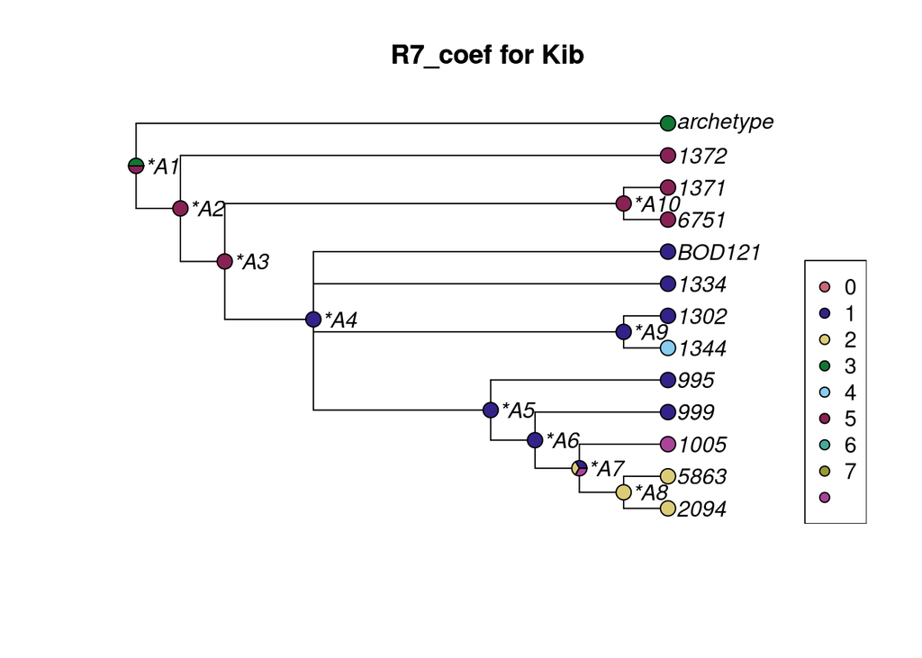

**Legend**

1. ―
2. 12 w/ filler
3. 12/13
4. 12/13#
5. 13

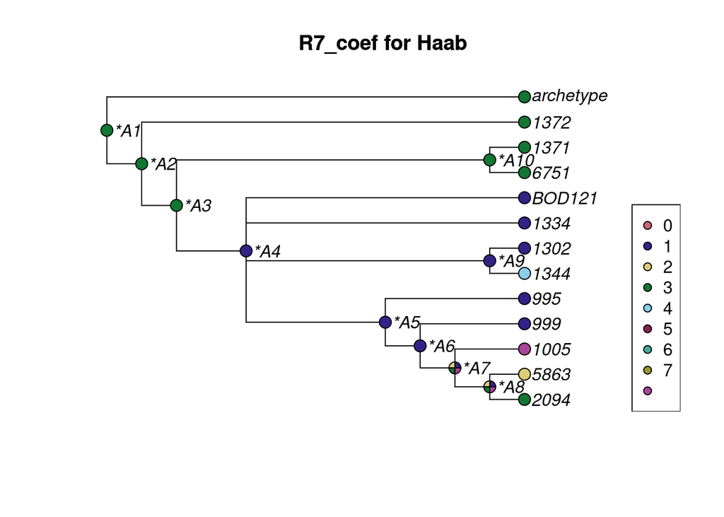

**Legend**

1. ―
2. 12 w/ filler
3. 19
4. Ø

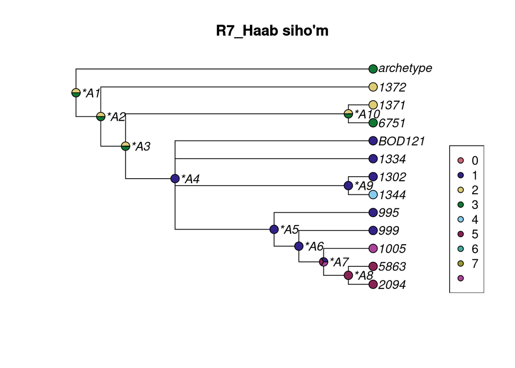

**Legend**

1. ―
2. [IK’]SIH
3. [IK’]SIH-ma
4. Ø
5. SIH-ma

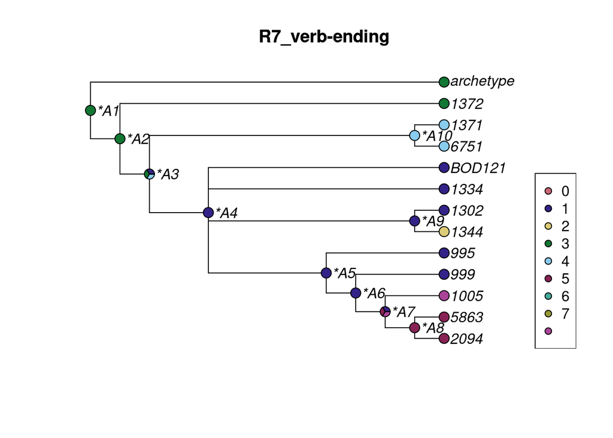

**Legend**

1. ―
2. la
3. Ø
4. wa
5. ya

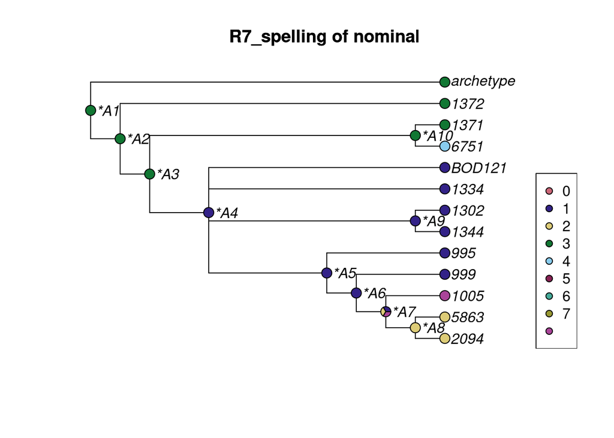

**Legend**

1. ―
2. #-xi-#
3. a-xi-la
4. a-xi-ma

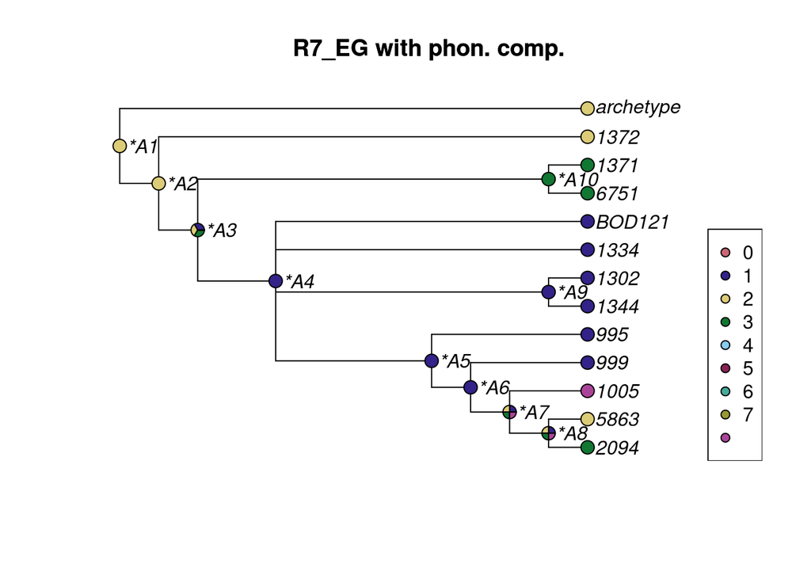

**Legend**

1. ―
2. la
3. Ø

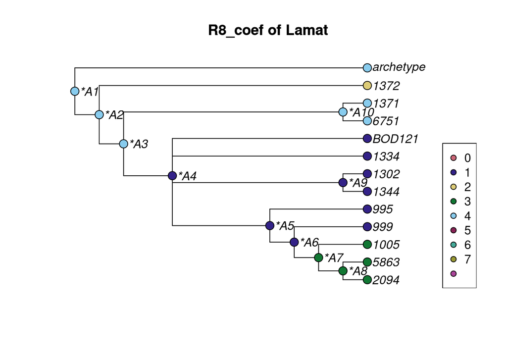

**Legend**

1. ―
2. 11 w/ fillers
3. 12 w/ filler
4. 8

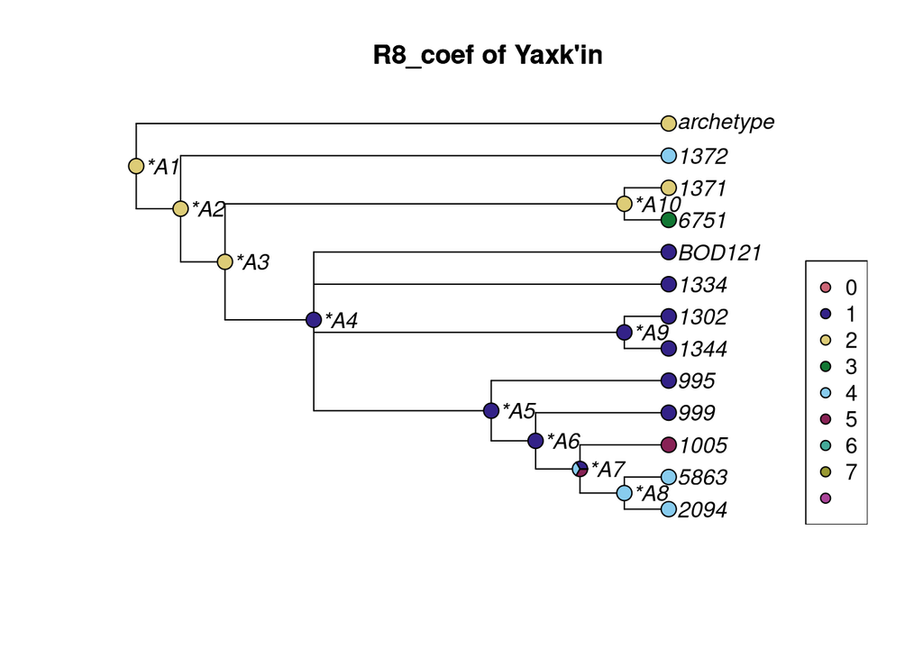

**Legend**

1. ―
2. 11
3. 11 w/ fillers
4. 12 w/ filler
5. 7 w/ filler

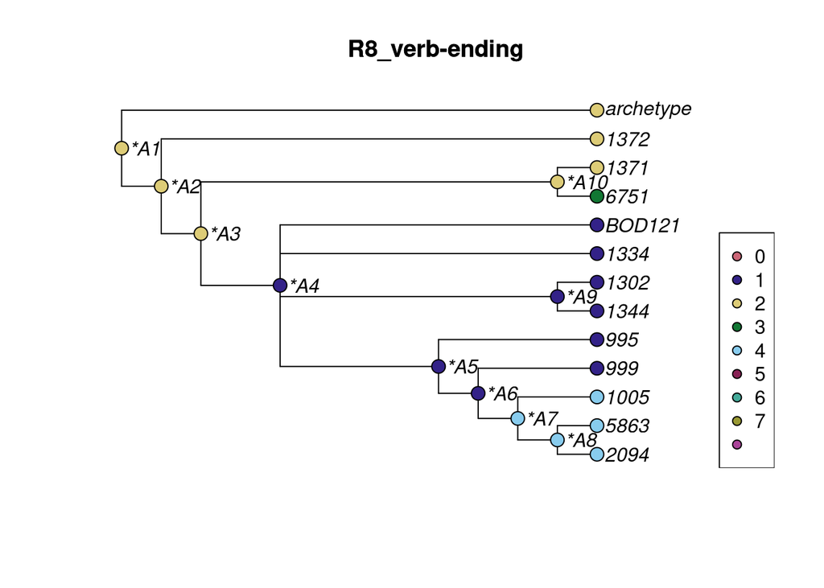

**Legend**

1. ―
2. Ø
3. wa
4. ya

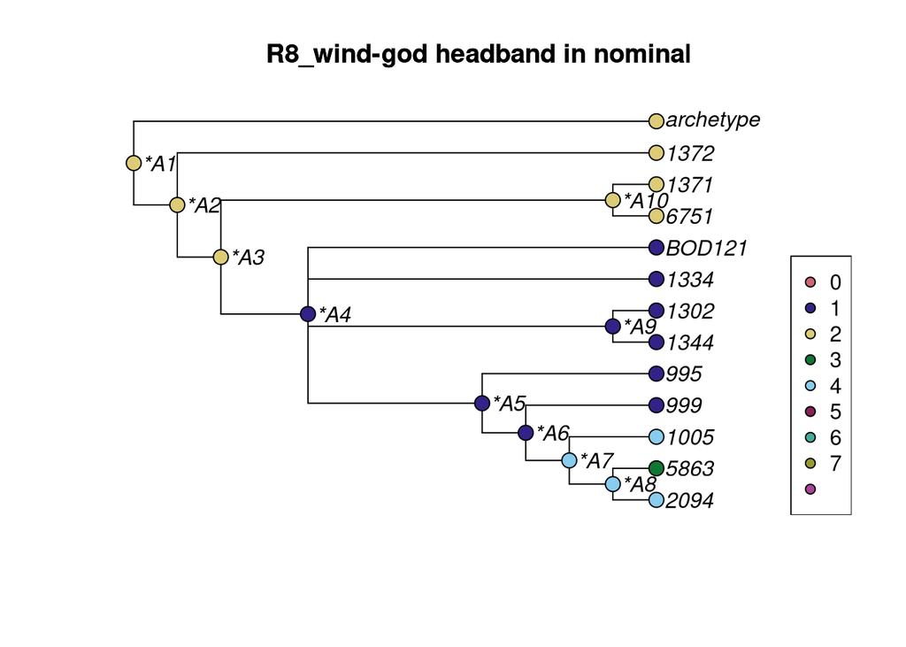

**Legend**

1. ―
2. No
3. Ø
4. Yes

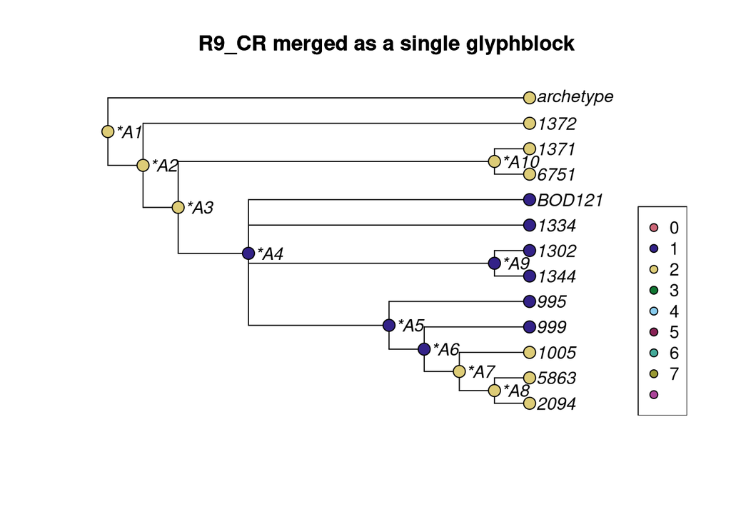

**Legend**

1. ―
2. Yes

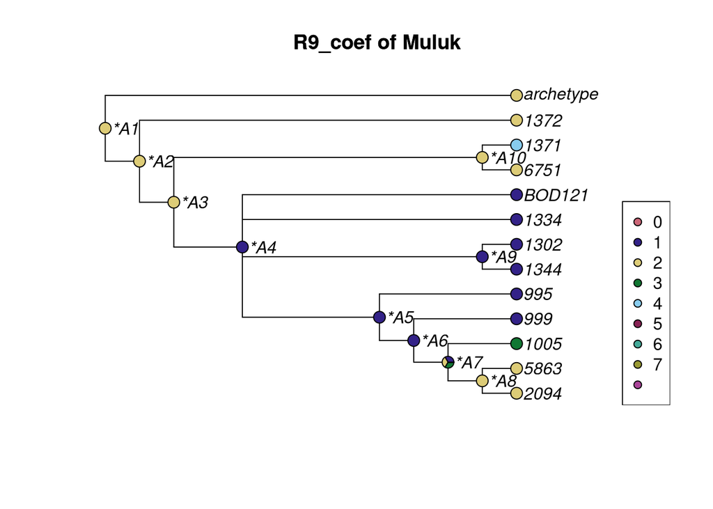

**Legend**

1. ―
2. 1
3. 1 w/ fillers
4. Ø

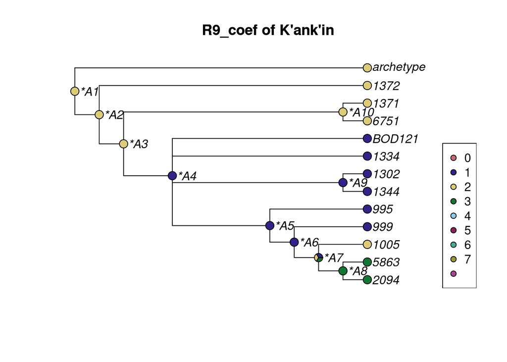

**Legend**

1. ―
2. 2
3. 3

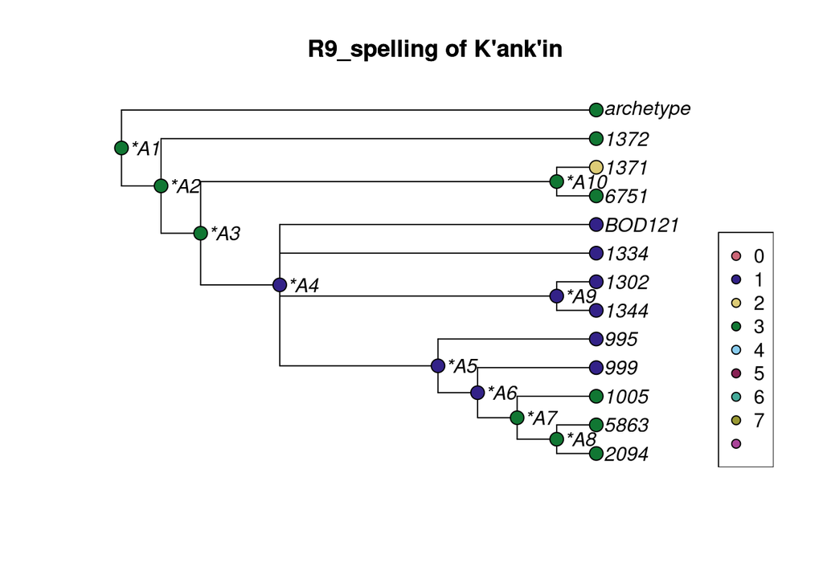

**Legend**

1. ―
2. UN-la
3. UN-wa

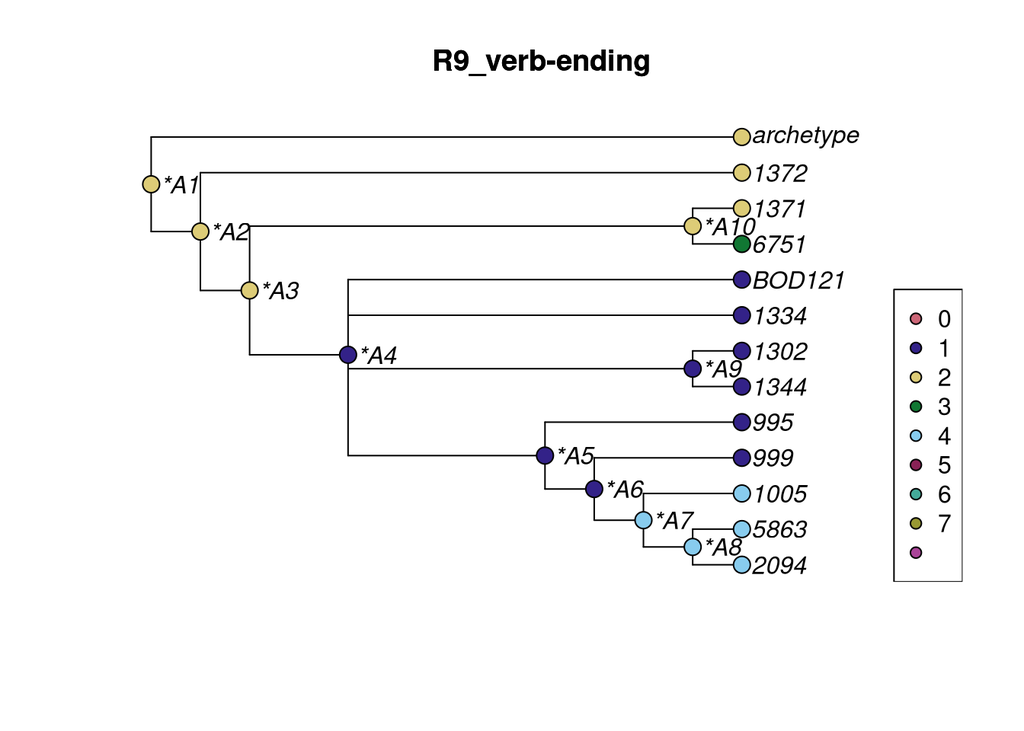

**Legend**

1. ―
2. la
3. wa
4. ya

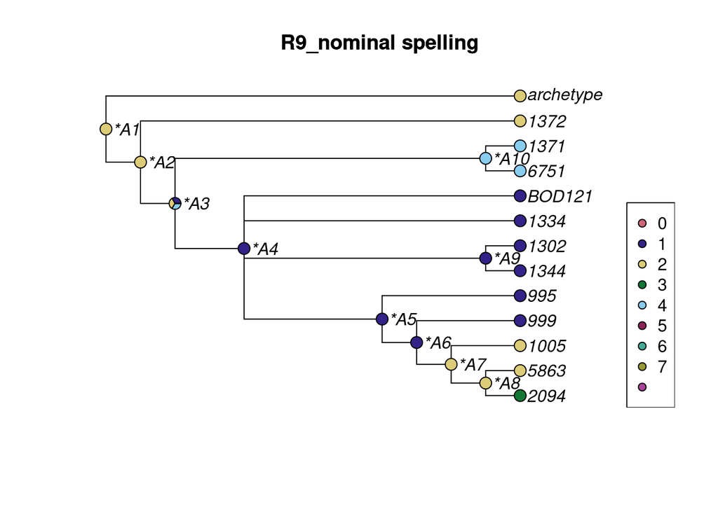

**Legend**

1. ―
2. AK’AB-OL-BALAM
3. AK’AB-OL-BALAM-ma
4. AK’AB-OL-la-BALAM-ma

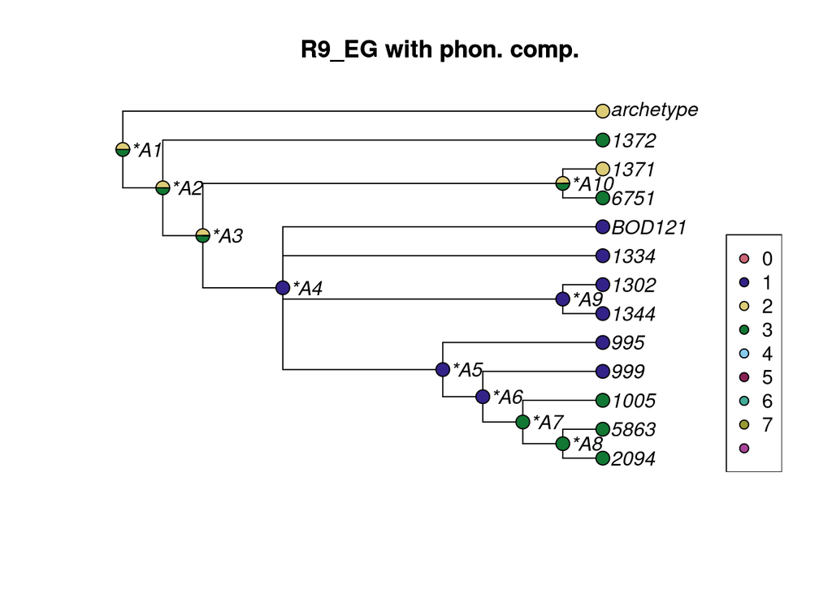

**Legend**

1. ―
2. la
3. Ø

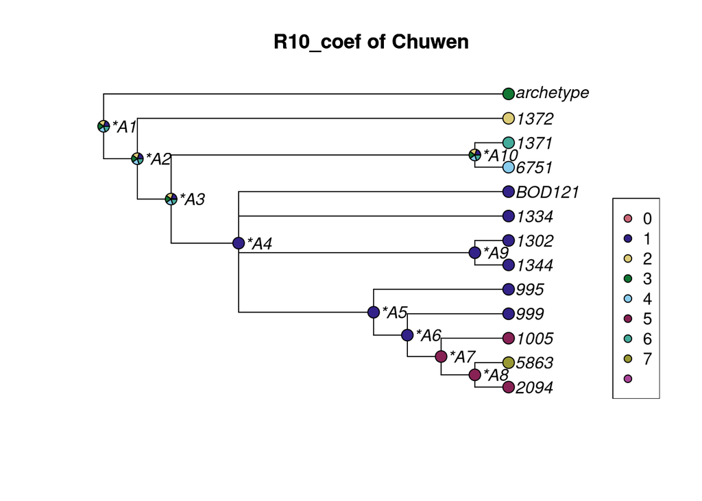

**Legend**

1. ―
2. 11 w/ fillers
3. 11/12
4. 12
5. 12 w/ filler
6. 6 w/ fillers
7. 7 w/ filler

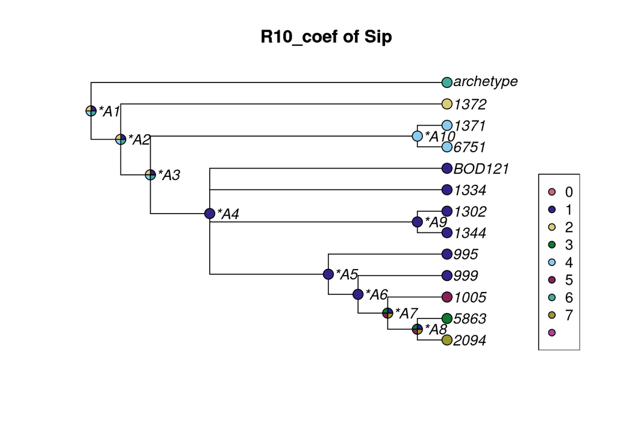

**Legend**

1. ―
2. 5#
3. 7 w/ filler
4. 8
5. 8#
6. 9
7. Ø

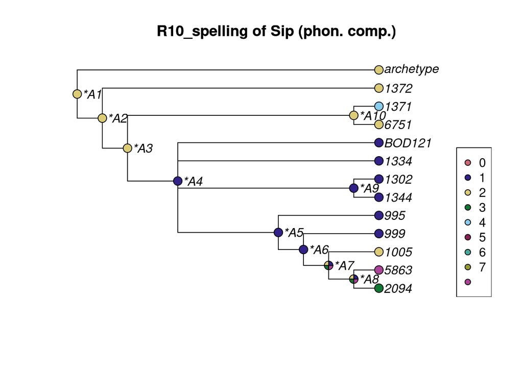

**Legend**

1. ―
2. la
3. Ø
4. ta?

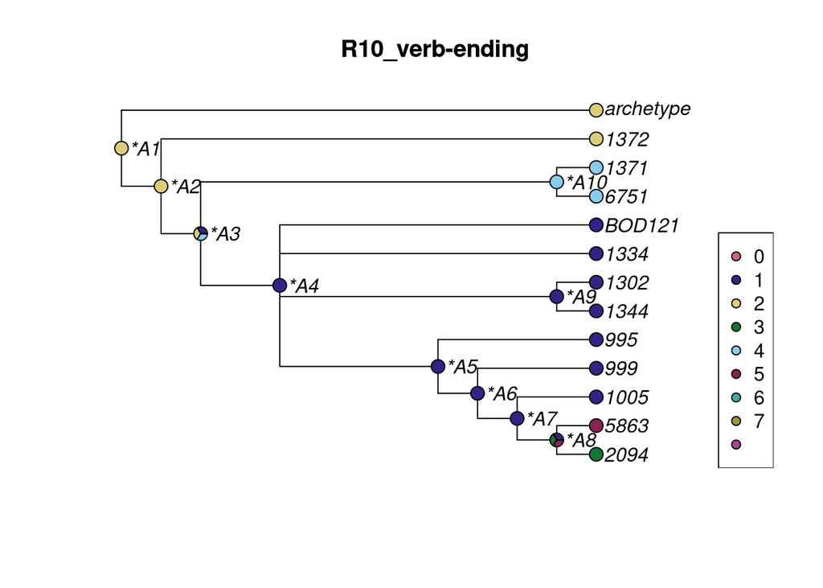

**Legend**

1. ―
2. la
3. Ø
4. wa
5. ya

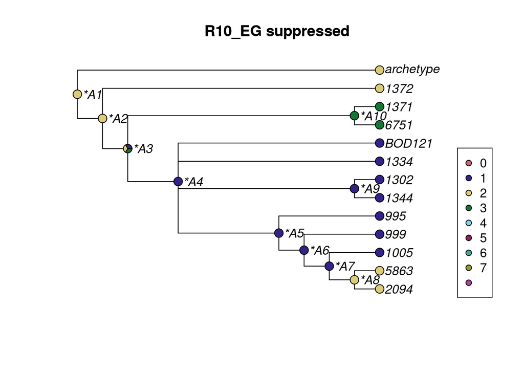

**Legend**

1. ―
2. No
3. Yes

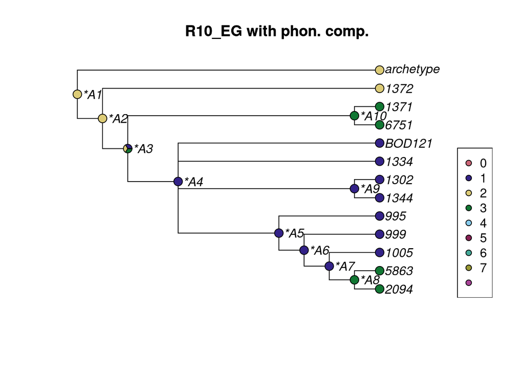

**Legend**

1. ―
2. la
3. Ø

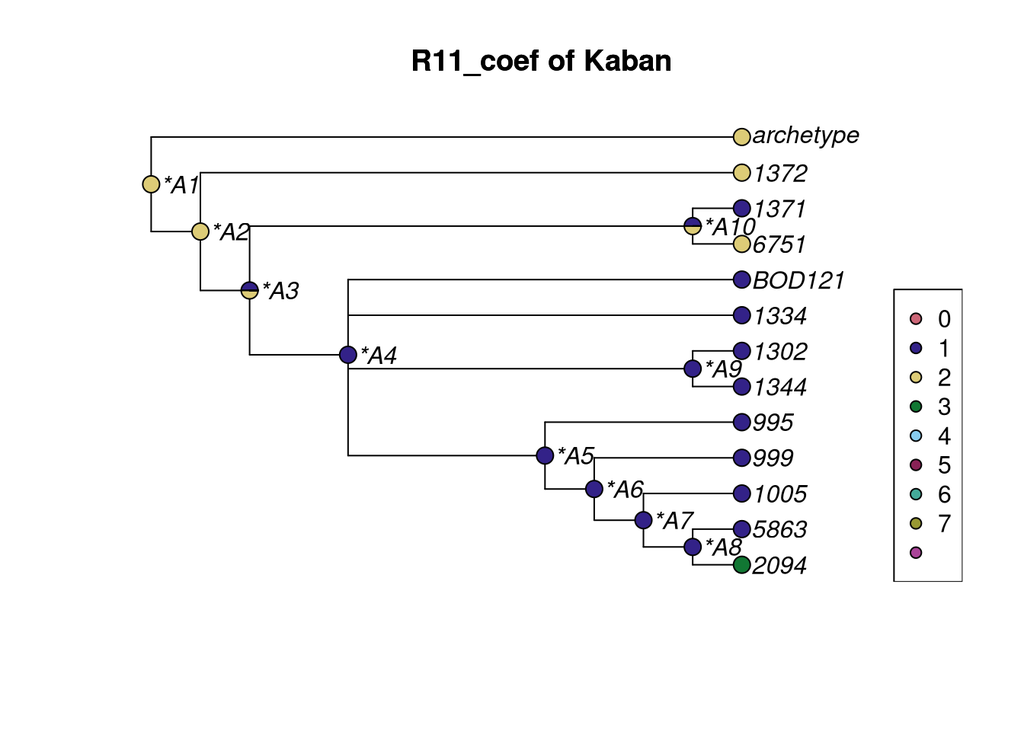

**Legend**

1. ―
2. 11
3. 7 w/ filler

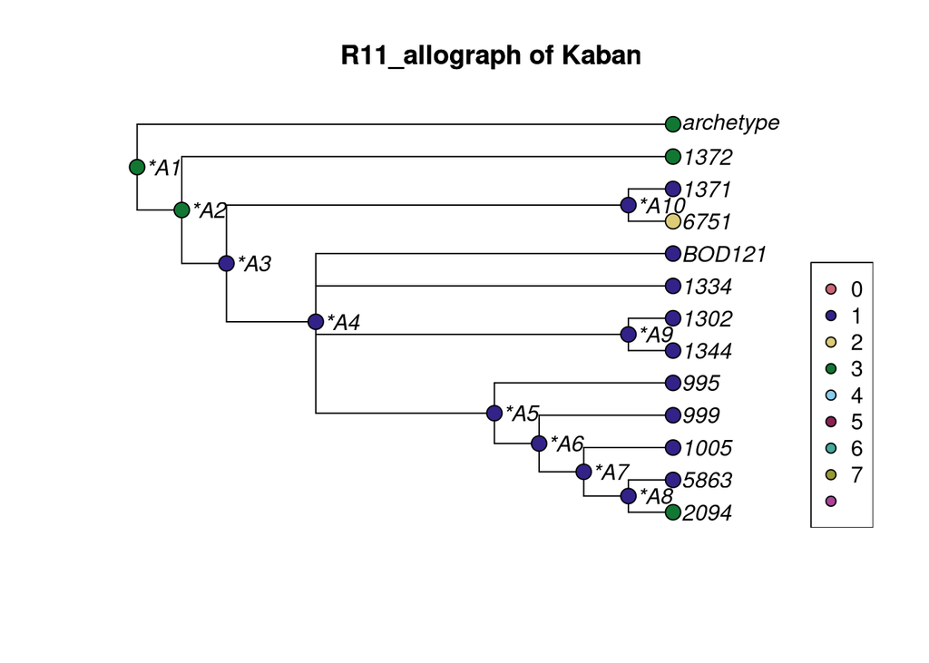

**Legend**

1. ―
2. asymmetric
3. symmetric

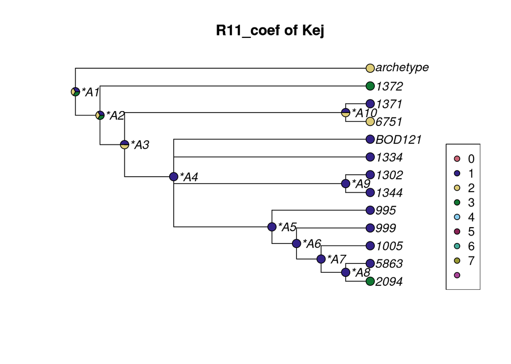

**Legend**

1. ―
2. 10
3. 12 w/ filler

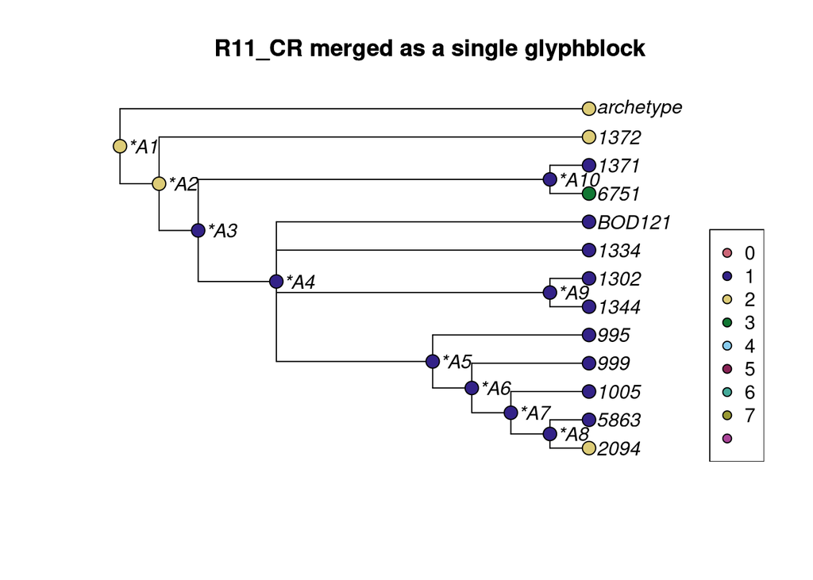

**Legend**

1. ―
2. No
3. Yes

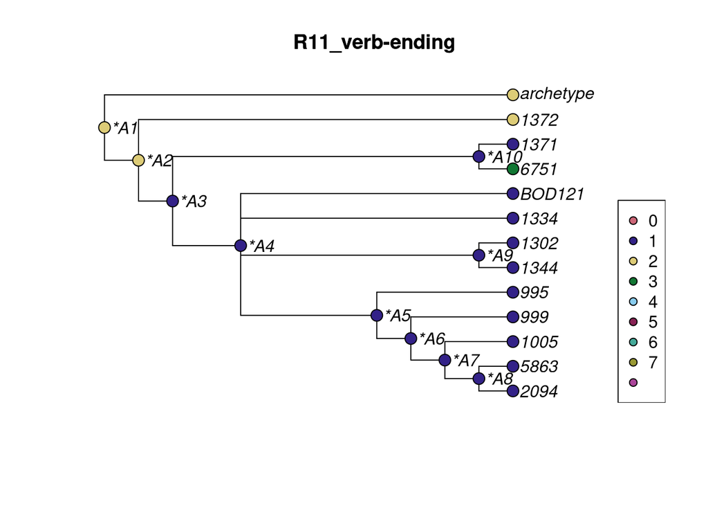

**Legend**

1. ―
2. la
3. wa

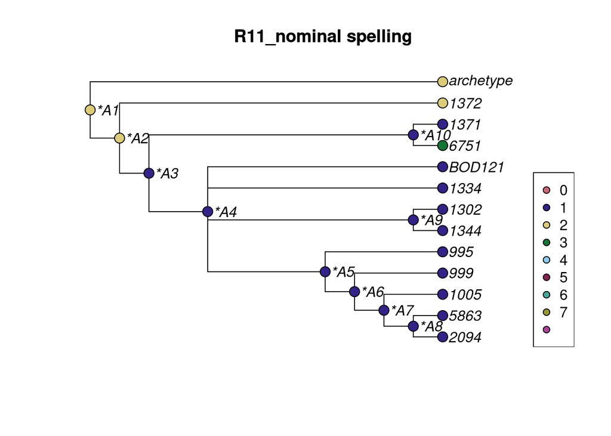

**Legend**

1. ―
2. ka-KAN-la
3. ka-KAN-nu

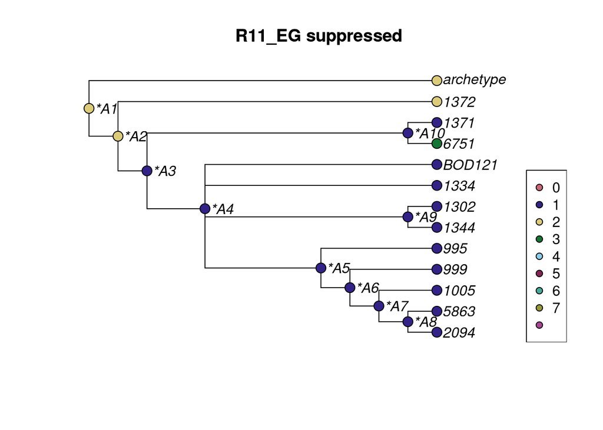

**Legend**

1. ―
2. No
3. Yes

## References

Collard, Mark, Stephen J. Shennan, and Jamshid J. Tehrani. 2006. “Branching, Blending, and the Evolution of Cultural Similarities and Differences Among Human Populations.” *Evolution and Human Behavior* 27 (3): 169–84. https://doi.org/10.1016/j.evolhumbehav.2005.07.003.

Grafen, Alan. 1989. “The Phylogenetic Regression.” *Philosophical Transactions of the Royal Society of London. B, Biological Sciences* 326 (1233): 119–57. https://doi.org/10.1098/rstb.1989.0106.

Hendy, M. D., and David Penny. 1982. “Branch and Bound Algorithms to Determine Minimal Evolutionary Trees.” *Mathematical Biosciences* 59 (2): 277–90. https://doi.org/10.1016/0025-5564(82)90027-X.

Paradis, Emmanuel, and Klaus Schliep. 2019. “ape 5.0: An Environment for Modern Phylogenetics and Evolutionary Analyses in R.” *Bioinformatics* 35: 526–28. https://doi.org/10.1093/bioinformatics/bty633.

R Core Team. 2025. *R: A Language and Environment for Statistical Computing*. Vienna, Austria: R Foundation for Statistical Computing. https://www.R-project.org/.

Schliep, Klaus. 2011. “phangorn: Phylogenetic Analysis in R.” *Bioinformatics* 27 (4): 592–93. https://doi.org/10.1093/bioinformatics/btq706.

Yu, Guangchuang. 2020. “Using ggtree to Visualize Data on Tree-Like Structures.” *Current Protocols in Bioinformatics* 69 (1): e96. https://doi.org/10.1002/cpbi.96.

———. 2022. *Data Integration, Manipulation and Visualization of Phylogenetic Treess*. 1st edition. Chapman; Hall/CRC. https://doi.org/10.1201/9781003279242.

Yu, Guangchuang, David Smith, Huachen Zhu, Yi Guan, and Tommy Tsan-Yuk Lam. 2017. “ggtree: An R Package for Visualization and Annotation of Phylogenetic Trees with Their Covariates and Other Associated Data.” *Methods in Ecology and Evolution* 8: 28–36. https://doi.org/10.1111/2041-210X.12628.